# act_report

## Report: act_report

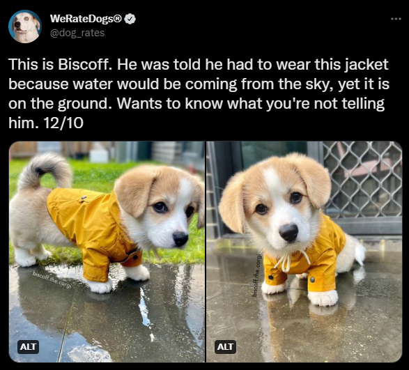

WeRateDogs or @dog_rates is a Twitter account that rates people's dogs with a humorous comment about the dog.this account created in November 2015, and became popular so fast and at this moment has more than 9.3 million followers.

There are four questions to answer in this report:

I Provide the answer below in the Insight:

#### Insight 1: Highest Source Used

98.1% of users use iphones when they post dog images, it's a high percentage compared to the rest of the sources, I think it has something to do with the quality of the iphone device camera.

#### Insight 2: Most Popular Dog Type

The most of dog type common among the users from the top 5 list is Golden Retriever with 139 images, I think that's because he looks cute and small size more than Labrador Retriever and pembroke.

#### Insight 3: The Common Dog Stage

Pupper is the most common dog stage in WeRateDogs tweets, there is a high difference among the rest of dog stage.